# Stock Market Predictions

Matthew Dunbar

2024-02-28

```r
library(xts)
library(DMwR2)
data(GSPC, package="DMwR2")
```

```r
first(GSPC)
```

```
##            GSPC.Open GSPC.High GSPC.Low GSPC.Close GSPC.Volume GSPC.Adjusted
## 1970-01-02     92.06     93.54    91.79         93     8050000            93
```

```r
last(GSPC)
```

```
##            GSPC.Open GSPC.High GSPC.Low GSPC.Close GSPC.Volume GSPC.Adjusted
## 2016-01-25   1906.28   1906.28  1875.97    1877.08  4401380000       1877.08
```

```r
library(quantmod)
T.ind <- function(quotes, tgt.margin = 0.025, n.days = 10) {
    v <- apply(HLC(quotes), 1, mean)
    v[1] <- Cl(quotes)[1]

    r <- matrix(NA, ncol = n.days, nrow = NROW(quotes))
    for (x in 1:n.days) r[, x] <- Next(Delt(v, k = x), x)

    x <- apply(r, 1, function(x) sum(x[x > tgt.margin | x < -tgt.margin]))

    if (is.xts(quotes)) xts(x, time(quotes)) else x}
```

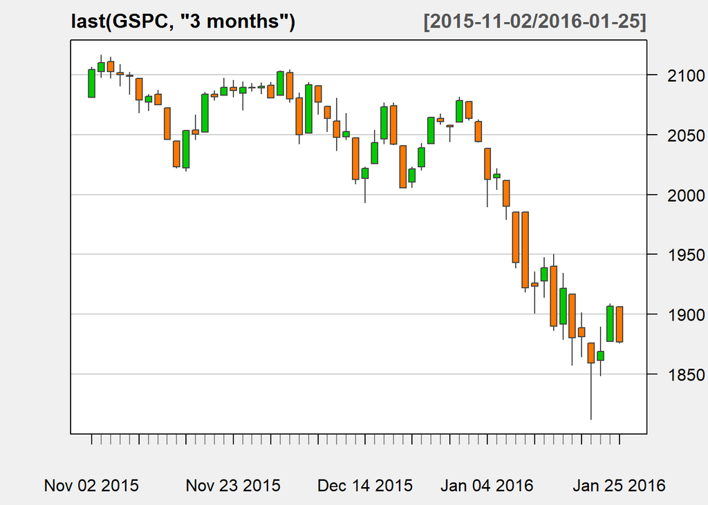

```r
candleChart(last(GSPC,'3 months'),theme='white', TA=NULL)
```

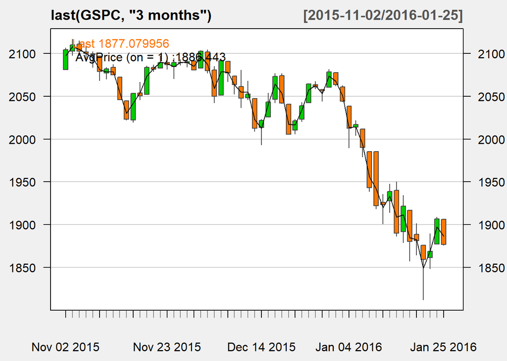

```r
avgPrice <- function(p) apply(HLC(p),1,mean)
addAvgPrice <- newTA(FUN=avgPrice,col=1,legend='AvgPrice')
addT.ind <- newTA(FUN=T.ind,col='red', legend='tgtRet')
addAvgPrice(on=1)
```

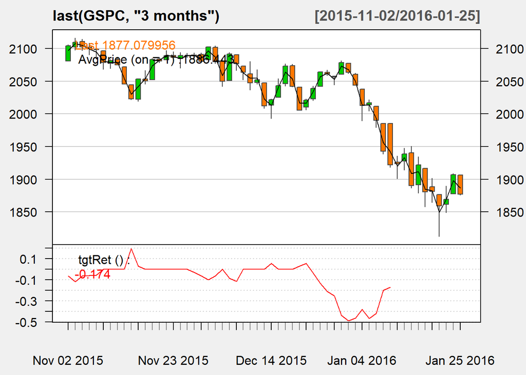

```r
addT.ind()
```

```r
library(TTR)
myATR        <- function(x) ATR(HLC(x))[,'atr']
mySMI        <- function(x) SMI(HLC(x))[, "SMI"]
myADX        <- function(x) ADX(HLC(x))[,'ADX']
myAroon      <- function(x) aroon(cbind(Hi(x),Lo(x)))$oscillator
myBB         <- function(x) BBands(HLC(x))[, "pctB"]
myChaikinVol <- function(x) Delt(chaikinVolatility(cbind(Hi(x),Lo(x))))[, 1]
myCLV        <- function(x) EMA(CLV(HLC(x)))[, 1]
myEMV        <- function(x) EMV(cbind(Hi(x),Lo(x)),Vo(x))[,2]
myMACD       <- function(x) MACD(Cl(x))[,2]
myMFI        <- function(x) MFI(HLC(x),  Vo(x))
mySAR        <- function(x) SAR(cbind(Hi(x),Cl(x))) [,1]
myVolat      <- function(x) volatility(OHLC(x),calc="garman")[,1]
```

```r
library(randomForest)
data.model <- specifyModel(T.ind(GSPC) ~ Delt(Cl(GSPC),k=1:10) +
        myATR(GSPC) + mySMI(GSPC) + myADX(GSPC) + myAroon(GSPC) +
        myBB(GSPC)  + myChaikinVol(GSPC) + myCLV(GSPC) +
        CMO(Cl(GSPC)) + EMA(Delt(Cl(GSPC))) + myEMV(GSPC) +
        myVolat(GSPC)  + myMACD(GSPC) + myMFI(GSPC) + RSI(Cl(GSPC)) +
        mySAR(GSPC) + runMean(Cl(GSPC)) + runSD(Cl(GSPC)))
set.seed(1234)
rf <- buildModel(data.model,method='randomForest',
                 training.per=c("1995-01-01","2005-12-30"),
                 ntree=1000, importance=TRUE)
```

```r
ex.model <- specifyModel(T.ind(IBM) ~ Delt(Cl(IBM), k = 1:3))
```

```r
data <- modelData(ex.model, data.window = c("2009-01-01", "2009-08-10"))
```

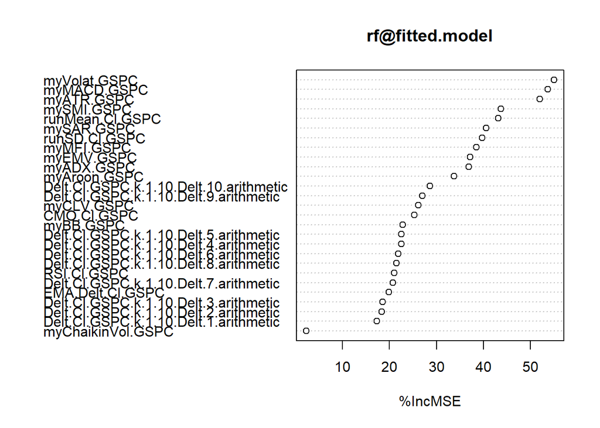

```r
varImpPlot(rf@fitted.model, type = 1)
```

```r
imp <- importance(rf@fitted.model, type = 1)
```

```r
rownames(imp)[which(imp > 30)]
```

```
##  [1] "myATR.GSPC"      "mySMI.GSPC"      "myADX.GSPC"      "myAroon.GSPC"
##  [5] "myEMV.GSPC"      "myVolat.GSPC"    "myMACD.GSPC"     "myMFI.GSPC"
##  [9] "mySAR.GSPC"      "runMean.Cl.GSPC" "runSD.Cl.GSPC"
```

```r
data.model <- specifyModel(T.ind(GSPC) ~ myATR(GSPC) + mySMI(GSPC) +  myADX(GSPC) + myAroon(GSPC) + myEMV(GSPC) + myVolat(GSPC) + myMACD(GSPC) + myMFI(GSPC) + mySAR(GSPC) + runMean(Cl(GSPC)) + runSD(Cl(GSPC)))
library(TTR)
```

```r
Tdata.train <- as.data.frame(modelData(data.model,
                                data.window=c('1970-01-02','2005-12-30')))
Tdata.eval <- na.omit(as.data.frame(modelData(data.model,
                                data.window=c('2006-01-01','2016-01-25'))))
Tform <- as.formula('T.ind.GSPC ~ .')
buy.thr <- 0.1
sell.thr <- -0.1
Tdata.trainC <- cbind(Signal=trading.signals(Tdata.train[["T.ind.GSPC"]], buy.thr,sell.thr),
Tdata.train[,-1])
Tdata.evalC <- cbind(Signal=trading.signals(Tdata.eval[["T.ind.GSPC"]],
buy.thr,sell.thr),
Tdata.eval[,-1])
TformC <- as.formula("Signal ~ .")
```

```r
set.seed(1234)
```

```r
library(nnet)
```

```r
norm.data <- data.frame(T.ind.GSPC=Tdata.train[[1]],scale(Tdata.train[,-1]))
```

```r
nn <- nnet(Tform, norm.data[1:1000, ], size = 5, decay = 0.01, maxit = 1000, linout = TRUE, trace = FALSE)
```

```r
preds <- predict(nn, norm.data[1001:2000, ])
```

```r
sigs.nn <- trading.signals(preds,0.1,-0.1)
```

```r
true.sigs <- trading.signals(Tdata.train[1001:2000, "T.ind.GSPC"], 0.1, -0.1)
```

```r
sigs.PR(sigs.nn,true.sigs)
```

```
##     precision    recall
## s   0.2809917 0.1931818
## b   0.3108108 0.2857143
## s+b 0.2973978 0.2373887
```

```r
set.seed(1234)
```

```r
library(nnet)
```

```r
norm.data <- data.frame(Signal=Tdata.trainC$Signal,scale(Tdata.trainC[,-1]))
```

```r
nn <- nnet(Signal ~ ., norm.data[1:1000, ], size = 10, decay = 0.01,    maxit = 1000, trace = FALSE)
```

```r
preds <- predict(nn, norm.data[1001:2000, ], type = "class")
```

```r
sigs.PR(preds, norm.data[1001:2000, 1])
```

[output not shown]

```r
set.seed(1234)
```

```r
library(e1071)
```

```r
sv <- svm(Tform, Tdata.train[1:1000, ], gamma = 0.001, cost = 100)
```

```r
s.preds <- predict(sv, Tdata.train[1001:2000, ])
```

```r
sigs.svm <- trading.signals(s.preds, 0.1, -0.1)
```

```r
true.sigs <- trading.signals(Tdata.train[1001:2000, "T.ind.GSPC"], 0.1, -0.1)
```

```r
sigs.PR(sigs.svm, true.sigs)
```

```
##     precision      recall
## s       0.375 0.017045455
## b         NaN 0.000000000
## s+b     0.375 0.008902077
```

```r
library(kernlab)
```

```r
ksv <- ksvm(Signal ~ ., Tdata.trainC[1:1000, ], C = 10)
ks.preds <- predict(ksv, Tdata.trainC[1001:2000, ])
sigs.PR(ks.preds, Tdata.trainC[1001:2000, 1])
```

```
##     precision    recall
## s   0.2365591 0.2500000
## b   0.3246753 0.1552795
## s+b 0.2623574 0.2047478
```

```r
library(earth)
e <- earth(Tform, Tdata.train[1:1000, ])
e.preds <- predict(e, Tdata.train[1001:2000, ])
sigs.e <- trading.signals(e.preds, 0.1, -0.1)
true.sigs <- trading.signals(Tdata.train[1001:2000, "T.ind.GSPC"], 0.1, -0.1)
```

```r
sigs.PR(sigs.e, true.sigs)
```

```
##     precision    recall
## s   0.2894737 0.2500000
## b   0.3504274 0.2546584
## s+b 0.3159851 0.2522255
```

```r
summary(e)
```

```
## Call: earth(formula=Tform, data=Tdata.train[1:1000,])
##
##                           coefficients
## (Intercept)                  0.5241811
## h(myATR.GSPC-2.56817)        1.2724353
## h(-61.825-mySMI.GSPC)        0.0594203
## h(myADX.GSPC-40.6215)       -0.0104803
## h(50.657-myADX.GSPC)        -0.0025279
## h(myADX.GSPC-50.657)         0.0823181
## h(0.204717-myVolat.GSPC)    -0.5105416
## h(myVolat.GSPC-0.204717)    -5.6100523
## h(myVolat.GSPC-0.271459)     5.6725474
## h(mySAR.GSPC-74.7031)       -0.0693496
## h(87.944-mySAR.GSPC)        -0.0575104
## h(mySAR.GSPC-87.944)         0.0800171
## h(runMean.Cl.GSPC-79.265)    0.2074780
## h(81.942-runMean.Cl.GSPC)    0.1058493
## h(runMean.Cl.GSPC-81.942)   -0.2185753
##
## Selected 15 of 18 terms, and 6 of 11 predictors
## Termination condition: Reached nk 23
## Importance: myVolat.GSPC, runMean.Cl.GSPC, myATR.GSPC, mySMI.GSPC, ...
## Number of terms at each degree of interaction: 1 14 (additive model)
## GCV 0.01470628    RSS 13.86568    GRSq 0.3536668    RSq 0.38939
```

```r
evimp(e, trim=FALSE)
```

```
##                      nsubsets   gcv    rss
## myVolat.GSPC               13 100.0  100.0
## runMean.Cl.GSPC            13 100.0  100.0
## myATR.GSPC                 12  96.7   96.4
## mySMI.GSPC                 11  81.5   82.4
## mySAR.GSPC                  7  44.1   47.7
## myADX.GSPC                  5  57.8>  58.5>
## myAroon.GSPC-unused         0   0.0    0.0
## myEMV.GSPC-unused           0   0.0    0.0
## myMACD.GSPC-unused          0   0.0    0.0
## myMFI.GSPC-unused           0   0.0    0.0
## runSD.Cl.GSPC-unused        0   0.0    0.0
```

```r
policy.1 <- function(signals,market,opened.pos,money,
                     bet=0.2,hold.time=10,
                     exp.prof=0.025, max.loss= 0.05
)
{
  d <- NROW(market)
  orders <- NULL
  nOs <- NROW(opened.pos)

  if (!nOs && signals[d] == 'h') return(orders)


  if (signals[d] == 'b' && !nOs) {
    quant <- round(bet*money/market[d,'Close'],0)
    if (quant > 0)
      orders <- rbind(orders,
                      data.frame(order=c(1,-1,-1),order.type=c(1,2,3),
                                 val = c(quant,
                                         C1(market)[d]*(1+exp.prof),
                                         C1(market)[d]*(1-max.loss)
                                 ),
                                 action = c('open','close','close'),
                                 posID = c(NA,NA,NA)
                      )
      )
  } else if (signals[d] == 's' && !nOs) {

    need2buy <- sum(opened.pos[opened.pos[,'pos.type']==-1,
                               "N.stocks"])*market[d,'Close']
    quant <- round(bet*(money-need2buy)/market[d,'Close'],0)
    if (quant > 0)
      orders <- rbind(orders,
                      data.frame(order=c(-1,1,1),order.type=c(1,2,3),
                                 val = c(quant,
                                         C1(market)[d]*(1-exp.prof),
                                         C1(market)[d]*(1+max.loss)
                                 ),
                                 action = c('open','close','close'),
                                 posID = c(NA,NA,NA)
                      )
      )
  }


  if (nOs)
    for(i in 1:nOs) {
      if (d - opened.pos[i,'Odate'] >= hold.time)
        orders <- rbind(orders,
                        data.frame(order=-opened.pos[i,'pos.type'],
                                   order.type=1,
                                   val = NA,
                                   action = 'close',
                                   posID = rownames(opened.pos)[i]
                        )
        )
    }

  orders
}
```

```r
policy.2 <- function(signals,market,opened.pos,money,
                     bet=0.2,exp.prof=0.025, max.loss= 0.05
)
{
  d <- NROW(market)
  orders <- NULL
  nOs <- NROW(opened.pos)

  if (!nOs && signals[d] == 'h') return(orders)


  if (signals[d] == 'b') {
    quant <- round(bet*money/market[d,'Close'],0)
    if (quant > 0)
      orders <- rbind(orders,
                      data.frame(order=c(1,-1,-1),order.type=c(1,2,3),
                                 val = c(quant,
                                         C1(market)[d]*(1+exp.prof),
                                         C1(market)[d]*(1-max.loss)
                                 ),
                                 action = c('open','close','close'),
                                 posID = c(NA,NA,NA)
                      )
      )


  } else if (signals[d] == 's') {

    need2buy <- sum(opened.pos[opened.pos[,'pos.type']==-1,
                               "N.stocks"])*market[d,'Close']
    quant <- round(bet*(money-need2buy)/market[d,'Close'],0)
    if (quant > 0)
      orders <- rbind(orders, data.frame(or=c(-1,1,1),order.type=c(1,2,3),
                                 val = c(quant,
                                         C1(market)[d]*(1-exp.prof),
                                         C1(market)[d]*(1+max.loss)
                                 ),
                                 action = c('open','close','close'),
                                 posID = c(NA,NA,NA)
                      )
      )
  }

  orders
}
```

```r
start <- 1

len.tr <- 1000

len.ts <- 500

tr <- start:(start+len.tr-1)

ts <- (start+len.tr):(start+len.tr+len.ts-1)

data(GSPC)

date <- rownames(Tdata.train[start+len.tr,])

marketTP <- GSPC[paste(date,'/',sep='')][1:len.ts]

library(e1071)

s <- svm(Tform, Tdata.train[tr,], cost=10,gamma=0.01)

p <- predict(s, Tdata.train[ts,])

sig <- trading.signals(p, 0.1, -0.1)
```

# Not quite sure what the error is here, but I could not run the prediction. Here is my code and the error…

t1 <- trading.simulator(marketTP,signals = sig, policy.func = ‘policy.1’, policy.pars = list(exp.prof=0.05,bet=0.2,hold.time=30))

Error in if (quant > 0) orders <- rbind(orders, data.frame(order = c(1, : argument is of length zero

# What method is used to split the data into training and validation sets? Why do you think it was split this way and not via random sample selection across all years?

The Train Test Split is the method to splitting data into a training dataset and a test dataset. I think the data was split the way it was because then the years are not a ranom assortment of years, but rather split between a subset of years 1970-2005 and 2006-2016.

# What is a confusion matrix and why is it helpful?

It is important because its used to explain the performance and accuracy of the model.

# In this case study, we create a few functions. What is the purpose of creating a function?

The purpose of creating a function is to make the code repeatable over and over again, instead of having to either re-write the code the next time, and to automate the process instead of having to copy and paste code.